# Connect1-Stigma Study

### Read data

This dataset only includes those who have a ‘yes’ consent form, did not ask to drop out, and do not have duplicated IDs (filtered in a previous pass).

### Filter data

Only include participants with known age and sex, aged 50+, and have never used a HA.

### Rename and/or recode variables for logistic regression

Note that the “social circle” questions have been recoded to a binary response because of the large numbers of “0” responses. This recoding classifies a participant as knowing nobody with that characteristic (0) or knowing at least one person with that characteristic (1).

### Missing data check before logistic regression

Ensure no missing cells for 27 predictors and 1 outcome (n=1917 cases are good). Note that LD_total is not included in this list of variables.

### Filter by hearing criterion

Include only participants with hearing loss (n=772; or 0.4027126 of 1917)

### Backtracking: Correlation between Listening Difficulty items

Note that Q20 is not included in the average as most participants are NA on this item.

```
##               Q13_C Q14_C Q15_C Q16_C Q17_C Q18_C Q19_C
## Q13_Corrected 1.00
## Q14_Corrected 0.63  1.00
## Q15_Corrected 0.40  0.51  1.00
## Q16_Corrected 0.38  0.59  0.52  1.00
## Q17_Corrected 0.34  0.43  0.52  0.50  1.00
## Q18_Corrected 0.46  0.61  0.57  0.64  0.55  1.00
## Q19_Corrected 0.39  0.54  0.59  0.60  0.57  0.77  1.00
```

### Backtracking: Correlation between Subjective Age items

```
##                   m.Q1_ m.Q2_ m.Q3_
## mild.Q1_Corrected 1.00
## mild.Q2_Corrected 0.66  1.00
## mild.Q3_Corrected 0.64  0.69  1.00
```

### Backtracking: Correlation between Age Stigma items

Note that Q4 doesn’t correlate well with other items and will be excluded from the average (composite) measure.

```
##                   m.Q4_ m.Q5_ m.Q6_ m.Q7_ m.Q8_
## mild.Q4_Corrected  1.00
## mild.Q5_Corrected -0.07  1.00
## mild.Q6_Corrected -0.07  0.58  1.00
## mild.Q7_Corrected  0.02  0.48  0.57  1.00
## mild.Q8_Corrected -0.02  0.51  0.59  0.69  1.00
```

### Backtracking: Correlation between Hearing Aid Stigma items

All items correlate well and are included in the average (composite) measure.

```
##                    m.Q9_ m.Q10 m.Q11 m.Q12
## mild.Q9_Corrected  1.00
## mild.Q10_Corrected 0.64  1.00
## mild.Q11_Corrected 0.63  0.72  1.00
## mild.Q12_Corrected 0.55  0.81  0.70  1.00
```

### Reference for method

Pronk M, Deeg DJH, Versfeld NJ, Heymans MW, Naylor G, Kramer SE. Predictors of Entering a Hearing Aid Evaluation Period: A Prospective Study in Older Hearing-Help Seekers. Trends Hear. 2017;21:2331216517744915. doi:10.1177/2331216517744915

Note from Marieke: The R package used for the Net Reclassification Improvement is PredictABEL, with the function *reclassification* (categorical variant).

### Constructing a “basic” model with predictors that are expected to play a role

The Listening Difficulty (LD_total) measure was not included here as it’s not a validated measure, unlike HHIE. PTA doesn’t seem to play a strong role.

```
## Analysis of Deviance Table
##
## Model: binomial, link: logit
##
## Response: Purchased_HA
##
## Terms added sequentially (first to last)
##
##
##                 Df Deviance Resid. Df Resid. Dev  Pr(>Chi)
## NULL                              771     760.26
## Age              1   10.226       770     750.04  0.001385 **
## HHIE_total       1   23.124       769     726.91 1.519e-06 ***
## PTA4_better_ear  1    0.008       768     726.91  0.928651
## ---
## Signif. codes:  0 '***' 0.001 '**' 0.01 '*' 0.05 '.' 0.1 ' ' 1
```

```
##                          OR        2.5 %     97.5 %
## (Intercept)     0.005009674 0.0009665975 0.02474243
## Age             1.044686422 1.0221185751 1.06829260
## HHIE_total      1.047438503 1.0265283723 1.06904155
## PTA4_better_ear 1.001137462 0.9760464599 1.02591752
```

Group differences on Age, HHIE and PTA4 between those who did not purchase (No) and those who did purchase (Yes) hearing aids.

```
## Group
##       No      Yes
## 68.69293 71.30000
```

```
## Group
##       No      Yes
## 15.07074 18.53333
```

```
## Group
##       No      Yes
## 34.85129 36.56500
```

### Checking correlations between predictors

```
##                      mld.A m.HHI m.PTA
## mild.Age              1.00
## mild.HHIE_total      -0.24  1.00
## mild.PTA4_better_ear  0.24  0.25  1.00
```

A backwards elimination procedure confirms that PTA isn’t a significant predictor, so the new “basic” model only includes two predictors (Age + HHIE).

```
## Start:  AIC=734.91
## Purchased_HA ~ Age + HHIE_total + PTA4_better_ear
##
##                   Df Deviance    AIC
## - PTA4_better_ear  1   726.91 732.91
## <none>                 726.91 734.91
## - Age              1   742.52 748.52
## - HHIE_total       1   747.25 753.25
##
## Step:  AIC=732.91
## Purchased_HA ~ Age + HHIE_total
##
##              Df Deviance    AIC
## <none>            726.91 732.91
## - Age         1   744.64 748.64
## - HHIE_total  1   750.04 754.04
```

```
##
## Call:  glm(formula = Purchased_HA ~ Age + HHIE_total, family = binomial("logit"),
##     data = mild)
##
## Coefficients:
## (Intercept)          Age   HHIE_total
##    -5.28442      0.04405      0.04665
##
## Degrees of Freedom: 771 Total (i.e. Null);  769 Residual
## Null Deviance:       760.3
## Residual Deviance: 726.9     AIC: 732.9
```

```
##
## Call:
## glm(formula = Purchased_HA ~ Age + HHIE_total, family = binomial("logit"),
##     data = mild)
##
## Deviance Residuals:
##     Min       1Q   Median       3Q      Max
## -1.3772  -0.6720  -0.5723  -0.4521   2.3219
##
## Coefficients:
##              Estimate Std. Error z value Pr(>|z|)
## (Intercept) -5.284417   0.815160  -6.483 9.01e-11 ***
## Age          0.044052   0.010619   4.149 3.34e-05 ***
## HHIE_total   0.046651   0.009767   4.776 1.78e-06 ***
## ---
## Signif. codes:  0 '***' 0.001 '**' 0.01 '*' 0.05 '.' 0.1 ' ' 1
##
## (Dispersion parameter for binomial family taken to be 1)
##
##     Null deviance: 760.26  on 771  degrees of freedom
## Residual deviance: 726.91  on 769  degrees of freedom
## AIC: 732.91
##
## Number of Fisher Scoring iterations: 4
```

### Checking variance inflation factors

Predictors in the “basic” model are not multicollinear (VIF < 5).

```
##        Age HHIE_total
##   1.063945   1.063945
```

### Obtaining predictions from the “basic” model

Predicted outcomes are continuous scores, and must be converted to binary outcomes (1 or 0). Only 0.1943005 of participants obtained hearing aids in this sample, so the threshold at which a predicted response is considered a “yes” (1) is set to ≥0.1943, otherwise in a logistic regression model the threshold might typically be set to ≥0.5.

A few rows as an example:

```
##    purchase_outcome basic.fitted.results basic.fitted.results.bi
## 3                 0            0.3271621                       1
## 5                 1            0.1776930                       0
## 7                 1            0.3119881                       1
## 8                 1            0.2738914                       1
## 15                0            0.3439334                       1
## 17                1            0.1731824                       0
## 19                0            0.1857887                       0
## 20                0            0.1232308                       0
## 21                0            0.1877434                       0
## 23                0            0.2474382                       1
```

### Add one new predictor at a time to the basic model

As an example, this new model contains the added variable “Sex”. As before, continuous predictions are converted to binary outcomes.

```
##
## Call:
## glm(formula = Purchased_HA ~ Age + HHIE_total + Sex, family = binomial("logit"),
##     data = mild)
##
## Deviance Residuals:
##     Min       1Q   Median       3Q      Max
## -1.3401  -0.6761  -0.5686  -0.4493   2.3592
##
## Coefficients:
##              Estimate Std. Error z value Pr(>|z|)
## (Intercept) -5.177612   0.821015  -6.306 2.86e-10 ***
## Age          0.044065   0.010626   4.147 3.37e-05 ***
## HHIE_total   0.046927   0.009785   4.796 1.62e-06 ***
## Sex         -0.202564   0.187161  -1.082    0.279
## ---
## Signif. codes:  0 '***' 0.001 '**' 0.01 '*' 0.05 '.' 0.1 ' ' 1
##
## (Dispersion parameter for binomial family taken to be 1)
##
##     Null deviance: 760.26  on 771  degrees of freedom
## Residual deviance: 725.75  on 768  degrees of freedom
## AIC: 733.75
##
## Number of Fisher Scoring iterations: 4
```

### Example manual calculation of the Net Reclassification Improvement

With an added variable “Sex”, the Net Reclassification Improvement is 0.01839228.

```
##      basic.fitted.results.bi
##         0   1
##   No  408 214
##   Yes  60  90
```

```
##      new.fitted.results.bi
##         0   1
##   No  407 215
##   Yes  57  93
```

```
## [1] 0.01839228
```

### Using package PredictABEL to calculate the Net Reclassification Improvement

The “basic” model stays the same. The third variable in the “new” model should be changed to each of the 24 novel predictors of interest. There is no need to transform continuous predicted values to binary outcomes, as the threshold can be specified in the *reclassification* function. The output from the *reclassification* function (NRI Categorical) should give the same proportion as the manual calculation. In addition, the function calculates a 95% C.I. and a probability value of this change in classification occurring. As an example, the below model includes the added variable “Sex”.

```
##  _________________________________________
##
##      Reclassification table
##  _________________________________________
##
##  Outcome: absent
##
##              Updated Model
## Initial Model [0,0.194) [0.194,1]  % reclassified
##     [0,0.194)       388        20               5
##     [0.194,1]        19       195               9
##
##
##  Outcome: present
##
##              Updated Model
## Initial Model [0,0.194) [0.194,1]  % reclassified
##     [0,0.194)        53         7              12
##     [0.194,1]         4        86               4
##
##
##  Combined Data
##
##              Updated Model
## Initial Model [0,0.194) [0.194,1]  % reclassified
##     [0,0.194)       441        27               6
##     [0.194,1]        23       281               8
##  _________________________________________
##
##  NRI(Categorical) [95% CI]: 0.0184 [ -0.0291 - 0.0659 ] ; p-value: 0.44778
##  NRI(Continuous) [95% CI]: 0.0941 [ -0.0834 - 0.2716 ] ; p-value: 0.2988
##  IDI [95% CI]: 0.0017 [ -0.0014 - 0.0048 ] ; p-value: 0.28865
```

Repeat *reclassification* function for all novel predictors and note the NRI values.

##### Table of NRI values for 24 novel predictors

| Predictor | NRI | p-value |
| --- | --- | --- |
| Sex | 0.0184 | 0.44778 |
| Edu | -0.0048 | 0.75415 |
| Married | -0.0198 | 0.06356 |
| Health | 0.0099 | 0.69573 |
| QoL | -0.0099 | 0.44037 |
| Help_neighbours | -0.0179 | 0.32219 |
| Help_problems | 0.0016 | 0.5636 |
| Concern | -0.0198 | 0.34444 |
| Lonely | -0.0329 | 0.09428 |
| Sub_Age_avg | 0.0131 | 0.45296 |
| Age_stigma_avg | -0.0131 | 0.11729 |
| HA_stigma_avg | 0.0133 | 0.58731 |
| Accomp | -0.0016 | 0.70542 |
| Soc_Suspect_HL | 0.0002 | 0.99246 |
| Soc_Know_HL | -0.0048 | 0.75152 |
| Soc_Discuss_HL | -0.0209 | 0.3981 |
| Soc_Hearing_test | -0.0083 | 0.29425 |
| Soc_Obtain_HA | -0.0133 | 0.25877 |
| Soc_Sometimes_use | -0.0131 | 0.15649 |
| Soc_Regular_use | -0.0149 | 0.4145 |
| Soc_Very_positive | -0.0048 | 0.86846 |
| Soc_Somewhat_positive | 0 | 1 |
| Soc_Somewhat_negative | -0.0165 | 0.161 |
| Soc_Very_negative | 0.0002 | 0.97563 |

### Final model

None of the novel predictors were helpful in improving prediction of outcomes. The basic model is the final model.

```
## Analysis of Deviance Table
##
## Model: binomial, link: logit
##
## Response: Purchased_HA
##
## Terms added sequentially (first to last)
##
##
##            Df Deviance Resid. Df Resid. Dev  Pr(>Chi)
## NULL                         771     760.26
## Age         1   10.226       770     750.04  0.001385 **
## HHIE_total  1   23.124       769     726.91 1.519e-06 ***
## ---
## Signif. codes:  0 '***' 0.001 '**' 0.01 '*' 0.05 '.' 0.1 ' ' 1
```

```
##                      OR        2.5 %     97.5 %
## (Intercept) 0.005069985 0.0009976398 0.02447641
## Age         1.045036975 1.0236924814 1.06726648
## HHIE_total  1.047756059 1.0279889426 1.06817258
```

##### Correctly and incorrectly predicted HA purchase outcomes in the “basic” model

```
##      basic.fitted.results.bi
##       PredictedNo PredictedYes
##   No          408          214
##   Yes          60           90
```

```
##      basic.fitted.results.bi
##       PredictedNo PredictedYes
##   No     65.59486     34.40514
##   Yes    40.00000     60.00000
```

### ROC curves: Age, HHIE-S, PTA4 (better ear)

Area Under Curve for Age = 0.586

Area Under Curve for HHIE-S = 0.604

Area Under Curve for PTA4 (better ear) = 0.58

Area Under Curve for Age + HHIE-S = 0.657

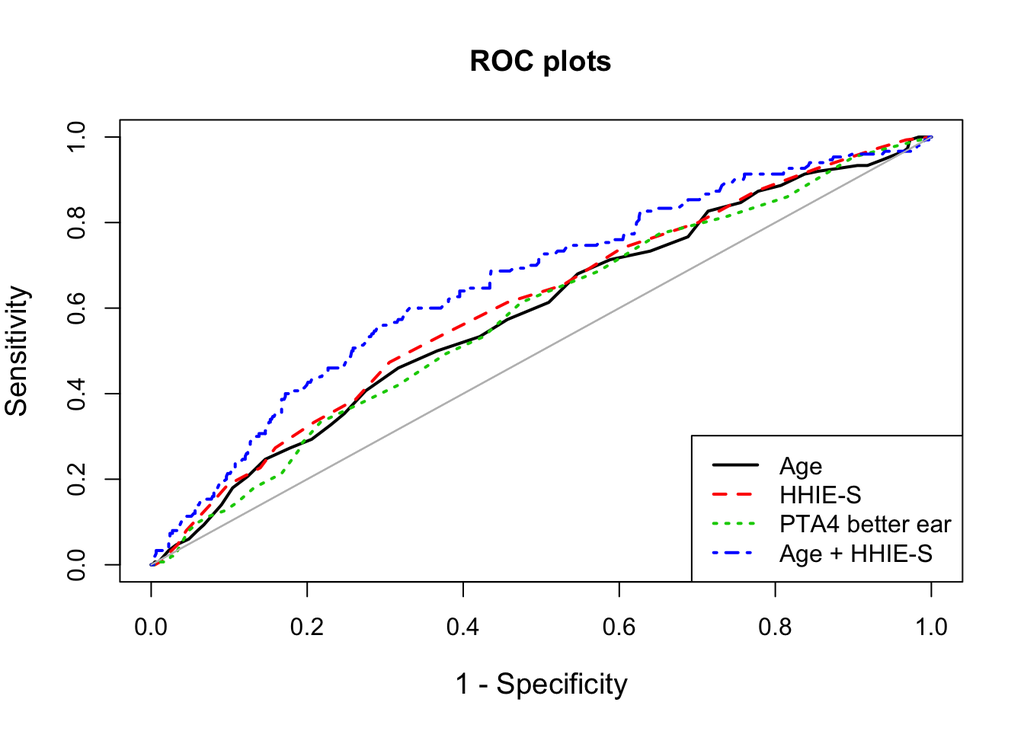

```
## AUC [95% CI] for the model 1 :  0.586 [ 0.536  -  0.637 ]
## AUC [95% CI] for the model 2 :  0.604 [ 0.555  -  0.654 ]
## AUC [95% CI] for the model 3 :  0.58 [ 0.529  -  0.63 ]
## AUC [95% CI] for the model 4 :  0.657 [ 0.608  -  0.706 ]
```

### Time to hearing aid purchase

The following relevant variables are available in the data from CH: - Date of most recent hearing evaluation - Date of 1st visit to the clinic - Date of most recent visit to the clinic - Purchase (Yes/No) - Date of Purchase - Date of Fitting Appointment There is a variable in the file called “Length of time between Survey and HA fitting” but the column contains no data.

Limiting the analysis to those who purchased hearing aids during the course of the study:

```
## [1] 150
```

Some people appear to be missing the date of “first visit”, whereas everybody has the date of “most recent” visit and the date of purchase.

```
## [1] 41
```

```
## [1] 0
```

```
## [1] 0
```

Splitting the group into those with “first visit” data, and those without.

For those with “first visit” data, the “first visit” is always before, or same as, “most recent”.

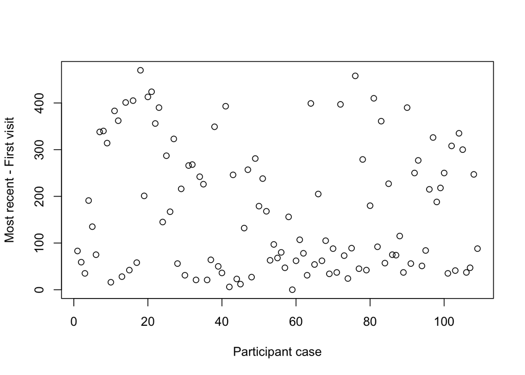

For those with “first visit” data, the “most recent” visit is usually after “HA purchase”.

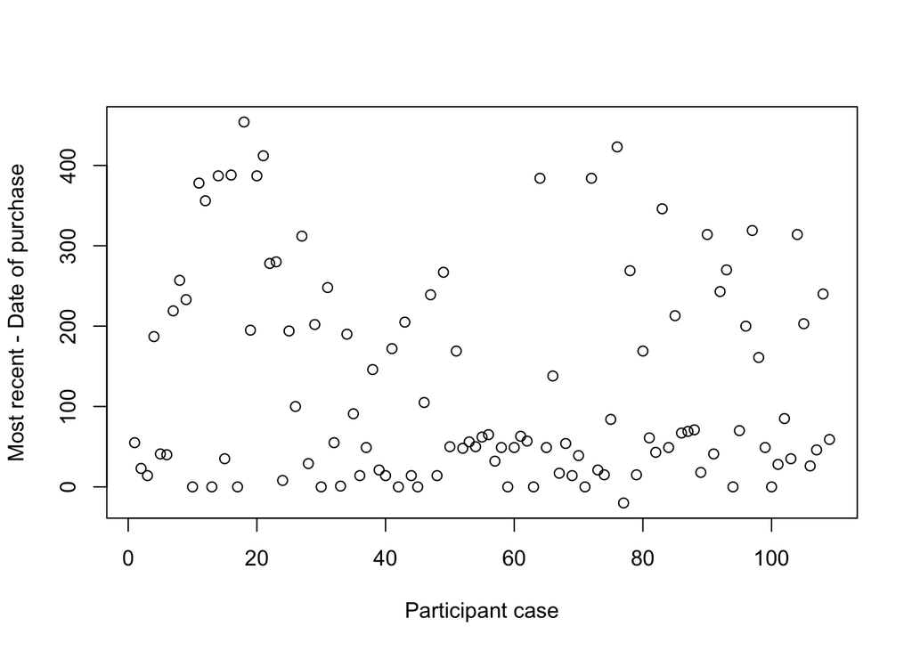

For those without “first visit” data, the “most recent” visit is usually after “HA purchase”.

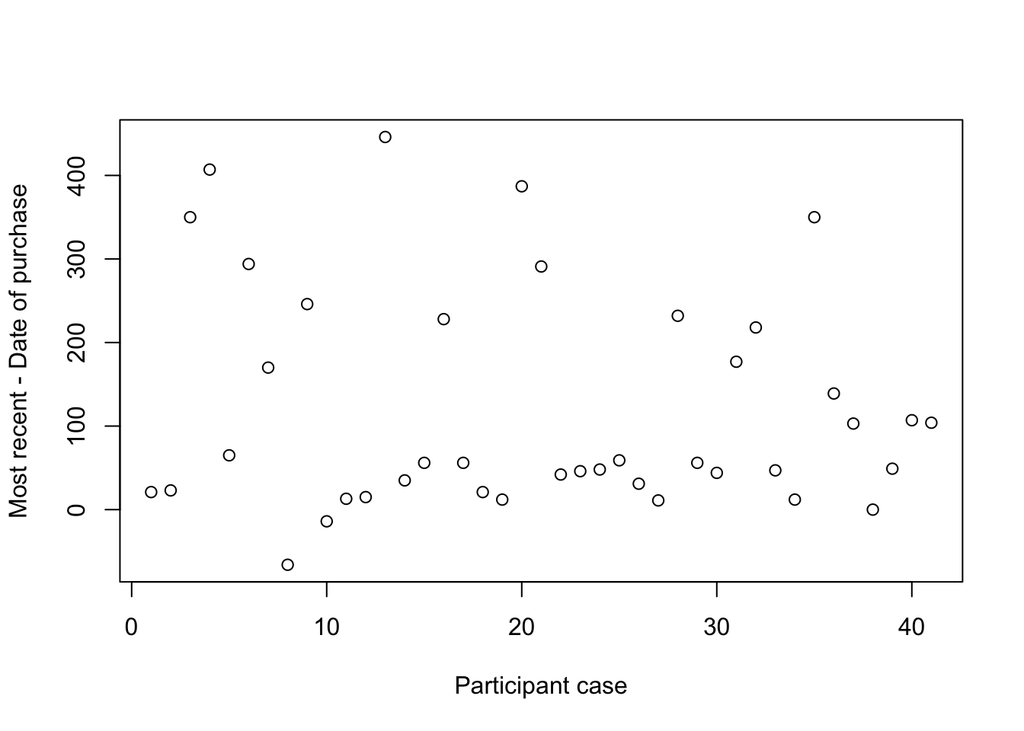

The first 10 rows of the raw time data, as an illustration.

```
##     date_firstvisit date_mostrecent date_purchase
## 5        2018-12-06      2019-02-27    2019-01-03
## 7              <NA>      2018-12-06    2018-11-15
## 8        2018-06-18      2018-08-16    2018-07-24
## 17       2018-05-08      2018-06-12    2018-05-29
## 37       2018-03-19      2018-09-26    2018-03-23
## 46       2018-04-30      2018-09-12    2018-08-02
## 64       2018-03-14      2018-05-28    2018-04-18
## 119      2018-03-14      2019-02-15    2018-07-11
## 143      2018-04-05      2019-03-11    2018-06-27
## 161      2018-03-16      2019-01-24    2018-06-05
```

For those with “first visit” data, the median time to purchase is 21 days, range 0 to 349 days.

```
##    Min. 1st Qu.  Median    Mean 3rd Qu.    Max.
##    0.00   11.00   21.00   46.29   52.00  349.00
```

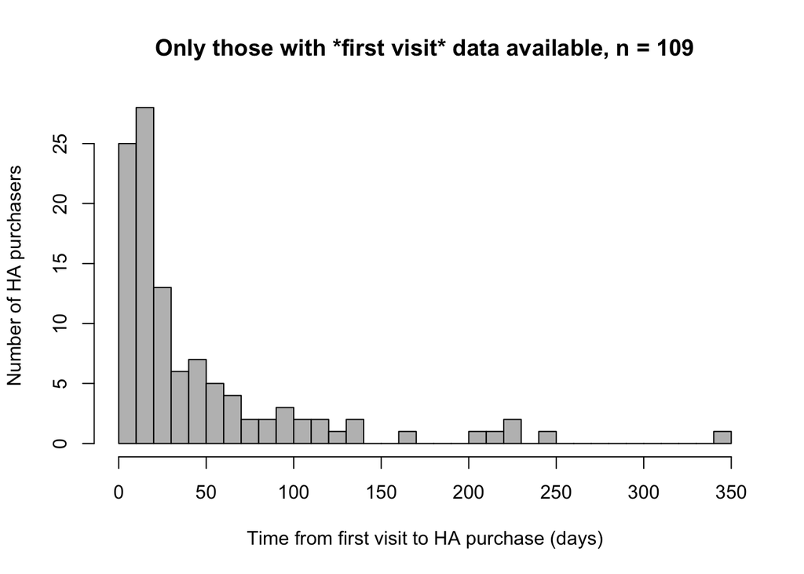

### Relationship between Age Stigma and Time to Purchase

Note: For n=109 with “first visit” data available.

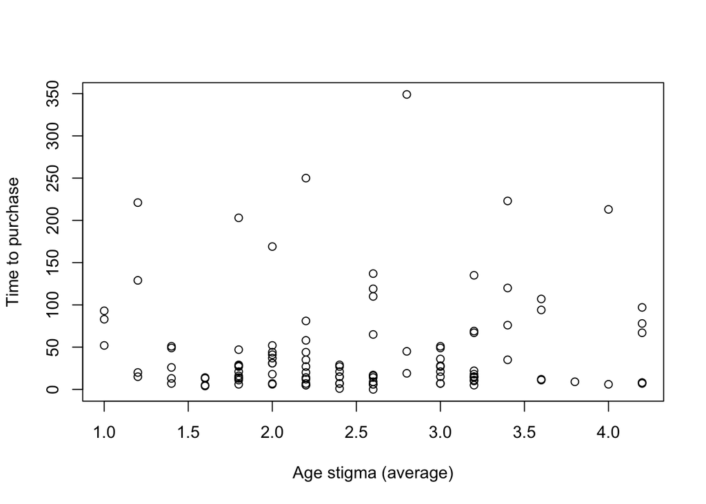

```
##
##  Pearson's product-moment correlation
##
## data:  yes1$Age_stigma_avg and yes1$time_to_purchase
## t = 0.43701, df = 107, p-value = 0.663
## alternative hypothesis: true correlation is not equal to 0
## 95 percent confidence interval:
##  -0.1470595  0.2284974
## sample estimates:
##        cor
## 0.04220986
```

### Relationship between Hearing Aid Stigma and Time to Purchase

Note: For n=109 with “first visit” data available.

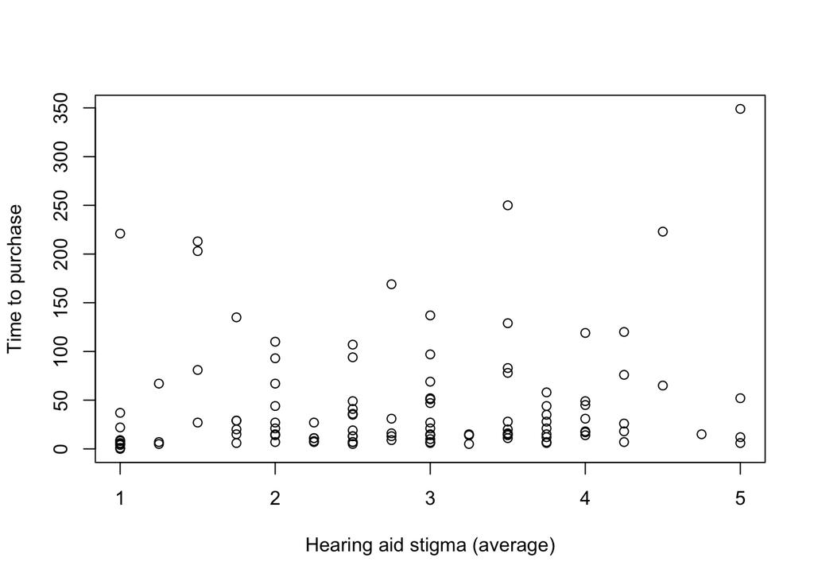

```
##
##  Pearson's product-moment correlation
##
## data:  yes1$HA_stigma_avg and yes1$time_to_purchase
## t = 1.1509, df = 107, p-value = 0.2523
## alternative hypothesis: true correlation is not equal to 0
## 95 percent confidence interval:
##  -0.07916818  0.29259589
## sample estimates:
##       cor
## 0.1105803
```